# GBIF-mediated data gaps in Sweden: Spatial, temporal and taxonomic gaps

Lena Thöle

2026-01-23

# 1 1. Scope and aim

This report assesses **data gaps in GBIF-mediated biodiversity occurrence data for Sweden**, focusing on:

- **Spatial gaps**: where are there no or low records?
- **Temporal gaps**: when are data missing, and how recent are records?
- **Taxonomic gaps**: which taxa (especially threatened taxa) are missing from GBIF-mediated data?

The analysis is based on: - **GBIF Occurrence Cube outputs** - **EEA reference grids** (10 km and 50 km) - **Swedish Red List taxonomy export** as reference for taxonomic gaps

# 2 2. Input data products used in this report

This report uses the following intermediate outputs:

## 2.1 Phase 2 (derived summaries)

- `data_proc/derived/cell_summary_10km.csv`
- `data_proc/derived/cell_summary_50km.csv`
- `data_proc/derived/time_summary_10km.csv`
- `data_proc/derived/time_summary_50km.csv`
- `data_proc/derived/species_summary_10km.csv`
- `data_proc/derived/species_summary_50km.csv`

## 2.2 Phase 3 (gap definitions)

- `data_proc/gaps/spatial_gaps_10km.csv`
- `data_proc/gaps/spatial_gaps_50km.csv`
- `data_proc/gaps/cell_recency_10km.csv`
- `data_proc/gaps/cell_recency_50km.csv`
- `data_proc/gaps/taxonomic_gap_summary.csv`
- `data_proc/gaps/missing_threatened_taxa.csv` (if available)

## 2.3 Phase 4 (overview tables)

These can optionally be created via:

```r
source("scripts/10_make_phase4_overview.R")
```

# 3 3. Gap definitions (summary)

Gap metric definitions are documented in:

- `docs/metrics.md`

In short, this report uses:

## 3.1 Spatial gaps

- **Zero coverage gap:** `occurrences == 0`
- **Low coverage gap:** among cells with `occurrences > 0`, the lowest 5% (`q05`) and 10% (`q10`)

## 3.2 Temporal gaps

- **Recency per cell:** last observation month per cell
- **Staleness thresholds:** no records in last 12 months / last 5 years

## 3.3 Taxonomic gaps

- Taxa from the Swedish reference list are considered **missing** if no match exists in cube taxa (string-matching approach)

# 4 4. Spatial gaps

## 4.1 4.1 Spatial gap summary (10 km)

```r
sp10 <- read_csv(file.path(p_gaps, "spatial_gaps_10km.csv"), show_col_types = FALSE)

sp10_all <- sp10 %>% filter(basisofrecord == "all")

sp10_all %>%
  summarise(
    n_cells = n(),
    pct_zero = round(100 * mean(gap_zero, na.rm = TRUE), 2),
    pct_low_q05 = round(100 * mean(gap_low_q05, na.rm = TRUE), 2),
    pct_low_q10 = round(100 * mean(gap_low_q10, na.rm = TRUE), 2)
  )
```

```
## # A tibble: 1 × 4
##   n_cells pct_zero pct_low_q05 pct_low_q10
##     <int>    <dbl>       <dbl>       <dbl>
## 1    7693        0        17.6        17.6
```

## 4.2 4.2 Spatial gap summary (50 km)

```r
sp50 <- read_csv(file.path(p_gaps, "spatial_gaps_50km.csv"), show_col_types = FALSE)

sp50_all <- sp50 %>% filter(basisofrecord == "all")

sp50_all %>%
  summarise(
    n_cells = n(),
    pct_zero = round(100 * mean(gap_zero, na.rm = TRUE), 2),
    pct_low_q05 = round(100 * mean(gap_low_q05, na.rm = TRUE), 2),
    pct_low_q10 = round(100 * mean(gap_low_q10, na.rm = TRUE), 2)
  )
```

```
## # A tibble: 1 × 4
##   n_cells pct_zero pct_low_q05 pct_low_q10
##     <int>    <dbl>       <dbl>       <dbl>
## 1     926        0        43.7        43.7
```

## 4.3 4.3 Spatial coverage intensity maps (quick check)

This section joins spatial gap outputs to the processed grid geometries and plots a basic intensity map.

### 4.3.1 10 km grid intensity

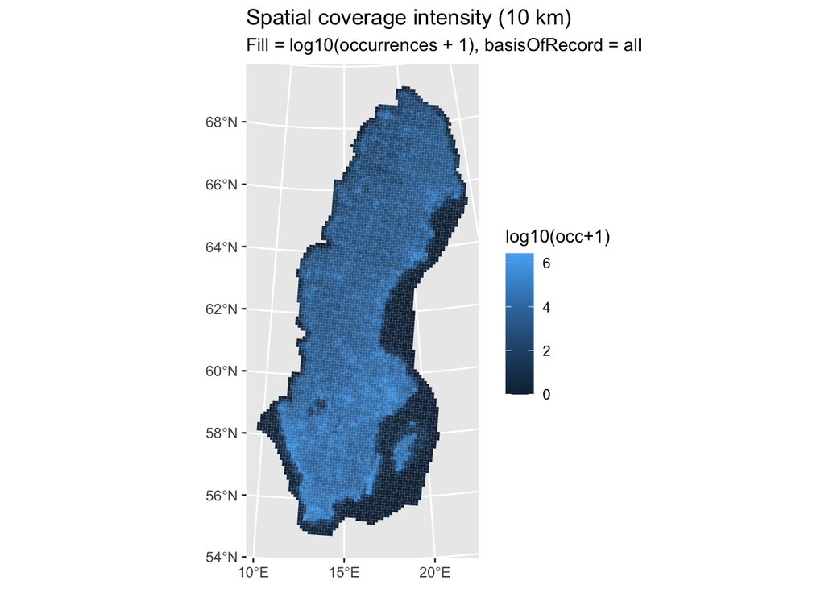

```r
grid10_path <- file.path(p_data_proc, "grids_10km.gpkg")
stopifnot(file.exists(grid10_path))

g10 <- st_read(grid10_path, quiet = TRUE)

# Guess join field containing the cell code
guess_code_field <- function(nms) {
  n <- tolower(nms)
  cand <- nms[grepl("eea", n) & grepl("code", n)]
  if (length(cand) > 0) return(cand[1])
  cand <- nms[grepl("cell", n) & grepl("code", n)]
  if (length(cand) > 0) return(cand[1])
  cand <- nms[grepl("eea|cell|code|grid", n)]
  if (length(cand) > 0) return(cand[1])
  NA_character_
}

code_field_10 <- guess_code_field(names(g10))
stopifnot(!is.na(code_field_10))

g10$eeacellcode <- as.character(g10[[code_field_10]])

map10 <- g10 %>%
  left_join(sp10_all %>% select(eeacellcode, occurrences, log_occ, gap_zero), by = "eeacellcode") %>%
  mutate(
    occurrences = coalesce(occurrences, 0),
    log_occ = coalesce(log_occ, 0),
    gap_zero = coalesce(gap_zero, TRUE)
  )

ggplot(map10) +
  geom_sf(aes(fill = log_occ), linewidth = 0) +
  labs(
    title = "Spatial coverage intensity (10 km)",
    subtitle = "Fill = log10(occurrences + 1), basisOfRecord = all",
    fill = "log10(occ+1)"
  )
```

# 5 5. Temporal gaps

## 5.1 5.1 National temporal trend (occurrences per year)

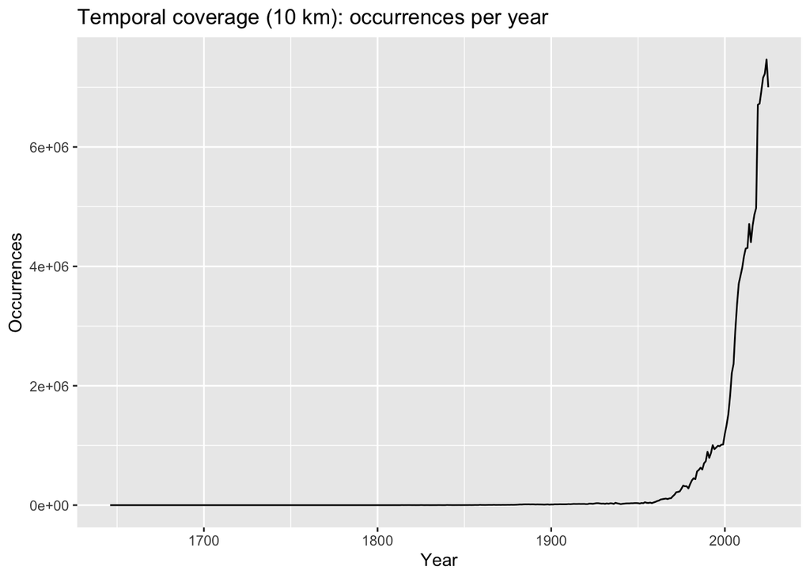

```r
ty10 <- read_csv(file.path(p_gaps, "temporal_overview_year_10km.csv"), show_col_types = FALSE)

ggplot(ty10, aes(x = year, y = occurrences)) +
  geom_line() +
  labs(
    title = "Temporal coverage (10 km): occurrences per year",
    x = "Year",
    y = "Occurrences"
  )
```

## 5.2 5.2 Seasonal bias (occurrences per month)

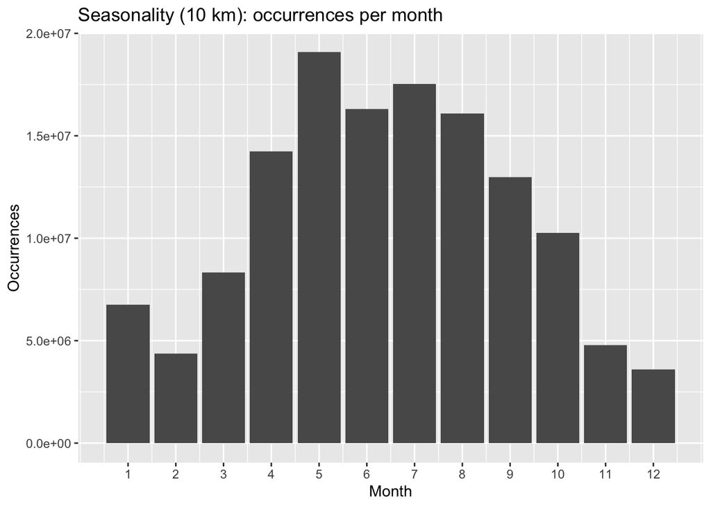

```r
tm10 <- read_csv(file.path(p_gaps, "temporal_overview_month_10km.csv"), show_col_types = FALSE)

ggplot(tm10, aes(x = month, y = occurrences)) +
  geom_col() +
  scale_x_continuous(breaks = 1:12) +
  labs(
    title = "Seasonality (10 km): occurrences per month",
    x = "Month",
    y = "Occurrences"
  )
```

## 5.3 5.3 Recency / staleness per grid cell (10 km)

```r
rec10 <- read_csv(file.path(p_gaps, "cell_recency_10km.csv"), show_col_types = FALSE) %>%
  filter(basisofrecord == "all")

rec10 %>%
  summarise(
    n_cells = n(),
    pct_stale_12m = round(100 * mean(gap_stale_12m, na.rm = TRUE), 2),
    pct_stale_5y = round(100 * mean(gap_stale_5y, na.rm = TRUE), 2),
    median_staleness = median(staleness_months, na.rm = TRUE)
  )
```

```
## # A tibble: 1 × 4
##   n_cells pct_stale_12m pct_stale_5y median_staleness
##     <int>         <dbl>        <dbl>            <dbl>
## 1    7693          36.2         23.5                4
```

# 6 6. Taxonomic gaps

## 6.1 6.1 Summary by rank and threat status

```r
tax_sum <- read_csv(file.path(p_gaps, "taxonomic_gap_summary.csv"), show_col_types = FALSE)

tax_sum %>% arrange(taxonRank, threatStatus) %>% head(30)
```

```
## # A tibble: 28 × 6
##    taxonRank        threatStatus n_ref n_matched_any n_missing pct_missing
##    <chr>            <chr>        <dbl>         <dbl>     <dbl>       <dbl>
##  1 species          CR             275           235        40       14.6
##  2 species          DD             899           710       189       21.0
##  3 species          EN             873           768       105       12.0
##  4 species          NT            1754          1590       164        9.35
##  5 species          RE             212           146        66       31.1
##  6 species          VU            1565          1367       198       12.6
##  7 species          <NA>          5315           874      4441       83.6
##  8 speciesAggregate CR               1             1         0        0
##  9 speciesAggregate DD               1             1         0        0
## 10 speciesAggregate NT               2             2         0        0
## # ℹ 18 more rows
```

## 6.2 6.2 Missing threatened taxa (CR/EN/VU)

```r
miss_thr_path <- file.path(p_gaps, "missing_threatened_taxa.csv")

if (file.exists(miss_thr_path)) {
  miss_thr <- read_csv(miss_thr_path, show_col_types = FALSE)
  miss_thr %>% select(scientificName, taxonRank, threatStatus) %>% head(50)
} else {
  cat("No missing_threatened_taxa.csv found.
")
}
```

```
## # A tibble: 50 × 3
##    scientificName         taxonRank threatStatus
##    <chr>                  <chr>     <chr>
##  1 Aelia rostrata         species   CR
##  2 Agriphila poliella     species   EN
##  3 Albatrellus cristatus  species   EN
##  4 Ampedus suecicus       species   VU
##  5 Andrena batava         species   VU
##  6 Andrena bluethgeni     species   EN
##  7 Andrena morawitzi      species   CR
##  8 Andrena nigrospina     species   VU
##  9 Anthothela grandiflora species   CR
## 10 Antrodiella citrinella species   CR
## # ℹ 40 more rows
```

# 7 7. Notes and limitations

- GBIF Occurrence Cube data represent **aggregated occurrence counts**, not true sampling effort.
- Spatial, temporal, and taxonomic coverage can be influenced by observer bias, accessibility, mobilization effort, and data publishing practices.
- Taxonomic matching in this phase uses **scientific name string matching**, which may undercount matches when synonyms or alternate spellings occur.

# 8 8. Next steps

Recommended next steps include: - basisOfRecord comparisons (humanObservation vs preservedSpecimen) - enhanced taxonomic mapping via GBIF backbone resolution - interpretation of gap patterns in relation to land cover, protected areas, or population density (optional)